# Do cockroaches care if they are being watched?

Jen Richmond

26/11/2020

# Summary

Social psychologists have long studied how the presence of other people can sometimes facilitate our performance and other times be detrimental. In his now famous drive theory, Zajonc (1965) argued that task complexity moderates the direction of the social facilitation/inhibition effect. When executing a simple learned response, our performance is typically enhanced by the presence of others, however, when we are learning a new task, having others watch us can put us off our game.

In seminal paper, [Zajonc, Heingartner, and Herman (1969)](https://psycnet.apa.org/record/1970-00434-001) reported that the interaction between task complexity and social facilitation was not a uniquely human phenomenon, but also extended to cockroaches. Here they tested cockroaches on a simple runway task or a complex maze task, either in the presence of other cockroaches or alone. Much like in humans, cockroaches ran the simple runway faster when others were watching, but were slower at completing the complex maze in the presence of others.

While this paper appears in textbooks and is highly cited, researchers have recently noted that the study was likely to be underpowered and that the key interaction between task difficulty and audience presence was never statistically tested. In a registered replication, [Halfmann, Bredehoft, & Hausser (2020)](https://journals.sagepub.com/doi/full/10.1177/0956797620902101) aimed to replicate the original study with a large sample and to test whether they could find evidence of a difficulty (simple, complex) x audience (present, absent) interaction.

In the replication study, Halfmann et al., (2020) tested 120 cockroaches, a sample 3 times the size of that used in the original paper. Using a between-subjects design, each roach was tested on either the runway or maze task, either in the presence of others or alone. Each roach completed 10 trials. The results showed that there were significant main effects of both task difficulty and audience presence. Roaches completed the runway task more quicklythan the maze task, and performed more slowly in the presence of others than when running alone. However, the task difficulty by audience interaction was not significant. Contrary to the original published paper, there was a social inhibition effect in both the runway and the maze task.

# Verification

I obtained the open data from the [OSF repository](https://osf.io/c7t6k) and attempted to reproduce the descriptive statistics reported on page 334.

> “In line with the descriptive data provided by Zajonc et al. (1969), our data showed that cockroaches needed more time to complete the maze (M = 137.48 s, SD = 121.88), compared with the easier runway (M = 77.00 s, SD = 76.16), F(1, 116) = 15.45, p < .001, ηp 2 = .12, BF10 = 20.79. Moreover, in the audience-present condition, cockroaches were slower (M = 164.59 s, SD = 98.84), compared with the audience-absent condition (M = 49.90 s, SD = 77.81), F(1, 116) = 55.58, p < .001, ηp 2 = .32, BF10 = 6.36e+7.”

I also reproduced the boxplot/scatter plot reported on page 335 of the paper.

[figure not shown]

```r
knitr::include_graphics(here::here("img", "boxscatter.png"))
```

## load packages

```r
library(here) # to help with file paths
library(haven) # to read files from spss
library(janitor) # to clean_names and count things
library(tidyverse) # for dplyr and ggplot
library(gt) # for nice tables
library(papaja) # for theme_apa
library(naniar) # for visualising missing data
library(ggeasy) # for easy ggplot functions
```

## read data

The data in the OSF repo is in .sav format. For this reason I need to use the `read_sav()` function from the `haven` package. I am using the `clean_names()` function from the `janitor` package to make the variable names consistently lower case with underscores in any gaps. The `glimpse()` function gives me a preview of the data structure and allows me to see what kind of data is in each variable.

```r
roaches <- read_sav(here("data", "roaches.sav")) %>%
  clean_names()

glimpse(roaches)
```

```
## Rows: 120
## Columns: 53
## $ vp_code         <chr> "001", "002", "003", "004", "005", "006", "007", "008…
## $ date_solo       <date> 2018-04-06, 2018-04-06, 2018-04-06, 2018-04-06, 2018…
## $ date_wg         <date> 2018-04-13, 2018-04-13, 2018-04-16, 2018-04-16, 2018…
## $ seperation_time <dbl> 7, 7, 10, 10, 10, 10, 10, 10, 11, 11, 11, 11, 12, 12,…
## $ task            <dbl+lbl> 1, 1, 1, 1, 1, 1, 1, 1, 1, 1, 1, 1, 1, 1, 1, 1, 1…
## $ goalbox         <dbl+lbl> 0, 0, 0, 0, 0, 0, 0, 0, 0, 0, 0, 0, 0, 0, 0, 0, 0…
## $ audien          <dbl+lbl> 1, 1, 1, 1, 1, 1, 1, 1, 1, 1, 1, 1, 1, 1, 1, 1, 1…
## $ name            <chr> "Trulla", "Euphresine", "Bella", "Maya", "Fee", "Merc…
## $ exclude         <dbl+lbl> 1, 1, 1, 1, 1, 1, 1, 1, 1, 1, 1, 1, 1, 1, 1, 1, 1…
## $ vp_nr           <dbl> 1, 2, 3, 4, 5, 6, 7, 8, 9, 10, 11, 12, 13, 14, 15, 16…
## $ sl01sek         <dbl> 30.68, 122.93, 17.00, 19.31, 16.58, 36.30, 4.06, 65.8…
## $ rt01sek         <dbl> 63.84, 147.44, 22.59, 28.41, 77.00, 52.34, 10.66, 176…
## $ rt_sl01         <dbl> 33.16, 24.51, 5.59, 9.10, 60.42, 16.04, 6.60, 110.73,…
```

[output cut: 40 more lines]

While the OSF repo did not include a data dictionary, the variable labels left behind from the SPSS file are somewhat useful in working out what each column contains. The experiment involved 120 roaches which were tested in a 2 task difficulty (maze, run) x 2 audience (present, absent) between subjects design.

There are 120 observations in the dataset and it looks like the “task” variable and the “audien” variable are the ones we care about. The data type on those two variables is interesting (dbl+lbl); that must be the label leftover from SPSS. Using the `unique()` function here to see what the values are in those columns?

```r
unique(roaches$task)
```

```
## <labelled<double>[2]>: Task difficulty: DV 1
## [1] 1 2
##
## Labels:
##  value  label
##      1 Runway
##      2   Maze
```

```r
unique(roaches$audien)
```

```
## <labelled<double>[2]>: Presence of audience: DV 2
## [1] 1 2
##
## Labels:
##  value            label
##      1 without audience
##      2    with audience
```

In both task and audience columns we have values of 1 and 2.

Task - 1 runway - 2 maze

Audience - 1 absent - 2 present

I am never going to remember what 1 and 2 refer to I am going to use `mutate()` and `case_when()` to make new columns called audience and difficulty. I am also going to move those new columns using the `relocate()` function. The `names()` function is a useful way of checking that your variables are where you expect them to be.

```r
roaches <- roaches %>%
  mutate(audience = case_when(audien == 1 ~ "absent",
                              audien == 2 ~ "present")) %>%
  mutate(difficulty = case_when(task == 1 ~ "runway",
                              task == 2 ~ "maze")) %>%
  relocate(c(audience, difficulty), .after = audien)

names(roaches)
```

```
##  [1] "vp_code"         "date_solo"       "date_wg"         "seperation_time"
##  [5] "task"            "goalbox"         "audien"          "audience"
##  [9] "difficulty"      "name"            "exclude"         "vp_nr"
## [13] "sl01sek"         "rt01sek"         "rt_sl01"         "sl02sek"
## [17] "rt02sek"         "rt_sl02"         "sl03sek"         "rt03sek"
## [21] "rt_sl03"         "sl04sek"         "rt04sek"         "rt_sl04"
## [25] "sl05sek"         "rt05sek"         "rt_sl05"         "sl06sek"
## [29] "rt06sek"         "rt_sl06"         "sl07sek"         "rt07sek"
## [33] "rt_sl07"         "sl08sek"         "rt08sek"         "rt_sl08"
## [37] "sl09sek"         "rt09sek"         "rt_sl09"         "sl10sek"
## [41] "rt10sek"         "rt_sl10"         "temp_th"         "air_th"
## [45] "temp_lab"        "air_lab"         "valid_t"         "invalid_t"
## [49] "comment"         "med_sl"          "med_rt"          "med_rt_sl"
## [53] "msl"             "mrt"             "mrt_sl"
```

I am expecting that with 120 roaches in a 2 x 2 design we should have 30 bugs in each group. Use the `tabyl()` function from the `janitor()` package to test that.

```r
roaches %>%
  tabyl(difficulty, audience)
```

```
##  difficulty absent present
##        maze     30      30
##      runway     30      30
```

In the paper, the authors talk about the problem of poor performance and needing to abandon the preregistered goal of only including roaches that had 8 good trials. They ending up settling for 2 good trials and even then, 17 roaches had to be excluded for failing to meet that threshold.

I am curious what the distribution of good trials like? Use `tabyl()` and `adorn_totals()` to count how many roaches had 2-10 good trials.

> NOTE: the authors of the original study didn’t report how many trials each roach completed or how many roaches were excluded from analysis. The sample in the original study was also small (N=10 in each group).

```r
valid <- roaches %>%
  tabyl(valid_t) %>%
  adorn_totals()

valid
```

```
##  valid_t   n    percent
##        2  11 0.09166667
##        3  11 0.09166667
##        4  11 0.09166667
##        5  12 0.10000000
##        6  10 0.08333333
##        7  10 0.08333333
##        8  16 0.13333333
##        9  17 0.14166667
##       10  22 0.18333333
##    Total 120 1.00000000
```

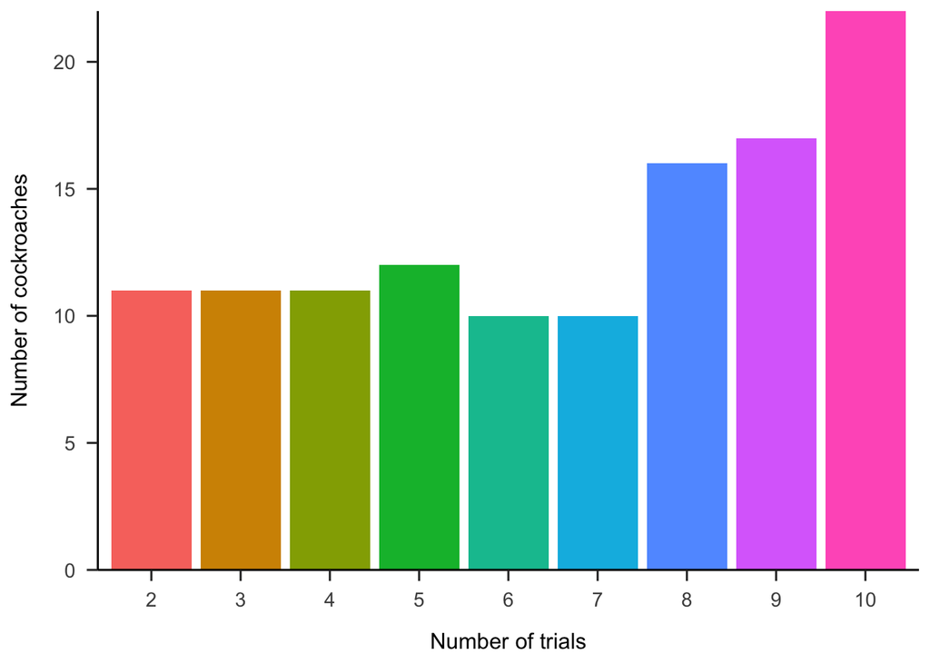

```r
valid %>%
  filter(valid_t %in% c(2:10)) %>%
  ggplot(aes(x = fct_inseq(valid_t), y = n, fill = fct_inseq(valid_t))) +
  geom_col() +
  labs(x = "Number of trials", y = "Number of cockroaches") +
  scale_y_continuous(expand = c(0,0)) +
  theme_apa() +
  easy_remove_legend()
```

## making sense of the dvs

The key dependent variable in the study is how long it took each roach to run the runway vs. the maze. Each roach ran 10 trials and there are three different DVs in the dataframe for each trial.

It is not clear which one was used in the analysis…

- sl01sek = how long did it take them to start running in trial 1.
- rt01sek = total run time trial 1
- rt_sl01 = runtime-startlatency (i.e. once they started moving, how long it took them to get to the end)

I assume the total run time DV was the one analysed, so I will start with that.

## reproducing descriptives

### run time

Here I made a new dataframe with only the key variables (subj, audience, difficulty) and the variables starting with “rt”, dropping those that start with “rt_sl”. Then I used `pivot_longer` to make the data long so that trial is represented in its own column.

```r
runtime <- roaches %>%
  select(vp_code, audience, difficulty, starts_with("rt"), -starts_with("rt_sl"))

runtime_long <- runtime %>%
  pivot_longer(names_to = "trial", values_to = "run_time", rt01sek:rt10sek)

glimpse(runtime_long)
```

```
## Rows: 1,200
## Columns: 5
## $ vp_code    <chr> "001", "001", "001", "001", "001", "001", "001", "001", "0…
## $ audience   <chr> "absent", "absent", "absent", "absent", "absent", "absent"…
## $ difficulty <chr> "runway", "runway", "runway", "runway", "runway", "runway"…
## $ trial      <chr> "rt01sek", "rt02sek", "rt03sek", "rt04sek", "rt05sek", "rt…
## $ run_time   <dbl> 63.84, 86.69, 219.10, 28.34, NA, 373.60, NA, 27.75, 48.97,…
```

In looking at the structure of the data with `glimpse()`, I can see that the key variables audience and difficulty are characters, rather than factors. Convert them to factors to make for easier plotting.

```r
runtime_long$difficulty <- as_factor(runtime_long$difficulty)

runtime_long$audience <- as_factor(runtime_long$audience)

glimpse(runtime_long)
```

```
## Rows: 1,200
## Columns: 5
## $ vp_code    <chr> "001", "001", "001", "001", "001", "001", "001", "001", "0…
## $ audience   <fct> absent, absent, absent, absent, absent, absent, absent, ab…
## $ difficulty <fct> runway, runway, runway, runway, runway, runway, runway, ru…
## $ trial      <chr> "rt01sek", "rt02sek", "rt03sek", "rt04sek", "rt05sek", "rt…
## $ run_time   <dbl> 63.84, 86.69, 219.10, 28.34, NA, 373.60, NA, 27.75, 48.97,…
```

Because the analysis reported main effects of task difficulty and audience, the descriptive statistics reported are median run times for the runway vs. maze task (averaged across present/absent) and median run times for audience present vs absent (averaged across runway/maze). Use `group_by()` and `summarise()` to get a median run times for each condition separately.

> The values reported in the paper are… - maze (M = 137.48 s, SD = 121.88) vs. runway (M = 77.00 s,SD = 76.16) - audience present (M = 164.59 s, SD = 98.84) vs audience absent (M = 49.90 s, SD = 77.81)

```r
runtime_long %>%
  group_by(difficulty) %>%
  summarise(med_runtime = median(run_time, na.rm = TRUE),
              stddev = sd(run_time, na.rm = TRUE))
```

```
## # A tibble: 2 x 3
##   difficulty med_runtime stddev
##   <fct>            <dbl>  <dbl>
## 1 runway            111.   148.
## 2 maze              194.   168.
```

```r
runtime_long %>%
  group_by(audience) %>%
  summarise(med_runtime = median(run_time, na.rm = TRUE),
              stddev = sd(run_time, na.rm = TRUE))
```

```
## # A tibble: 2 x 3
##   audience med_runtime stddev
##   <fct>          <dbl>  <dbl>
## 1 absent          83.3   111.
## 2 present        241.    170.
```

Those values don’t match. Perhaps they analysed the rt_sl variables?

### run time - start latency

As above, selecting just the key variables and making the data long so that trial is represented in a separate column.

```r
go_time <- roaches %>%
  select(vp_code, audience, difficulty, starts_with("rt_sl")) %>%
  pivot_longer(names_to = "trial", values_to = "go_time", rt_sl01:rt_sl10)
```

> The values I am trying to reproduce are … - maze (M = 137.48 s, SD = 121.88) vs. runway (M = 77.00 s,SD = 76.16) - audience present (M = 164.59 s, SD = 98.84) vs audience absent (M = 49.90 s, SD = 77.81)

```r
go_time %>%
  group_by(difficulty) %>%
  summarise(med_gotime = median(go_time, na.rm = TRUE),
              stddev = sd(go_time, na.rm = TRUE))
```

```
## # A tibble: 2 x 3
##   difficulty med_gotime stddev
##   <chr>           <dbl>  <dbl>
## 1 maze             79.6   150.
## 2 runway           29.9   123.
```

```r
go_time %>%
  group_by(audience) %>%
  summarise(med_gotime = median(go_time, na.rm = TRUE),
              stddev = sd(go_time, na.rm = TRUE))
```

```
## # A tibble: 2 x 3
##   audience med_gotime stddev
##   <chr>         <dbl>  <dbl>
## 1 absent         19.8   82.0
## 2 present       141.   147.
```

Those numbers don’t match either. Reading the paper again, it may be in the analysis they were using median, but the descriptives are mean and SD?

> The values reported in the paper are… - maze (M = 137.48 s, SD = 121.88) vs. runway (M = 77.00 s,SD = 76.16) - audience present (M = 164.59 s, SD = 98.84) vs audience absent (M = 49.90 s, SD = 77.81)

```r
go_time %>%
  group_by(difficulty) %>%
  summarise(mean_gotime = mean(go_time, na.rm = TRUE),
              stddev = sd(go_time, na.rm = TRUE))
```

```
## # A tibble: 2 x 3
##   difficulty mean_gotime stddev
##   <chr>            <dbl>  <dbl>
## 1 maze             146.    150.
## 2 runway            93.9   123.
```

```r
go_time %>%
  group_by(audience) %>%
  summarise(mean_gotime = mean(go_time, na.rm = TRUE),
              stddev = sd(go_time, na.rm = TRUE))
```

```
## # A tibble: 2 x 3
##   audience mean_gotime stddev
##   <chr>          <dbl>  <dbl>
## 1 absent          48.8   82.0
## 2 present        177.   147.
```

No, those values also don’t match. Maybe what they are doing is getting a median run time for each roach and then reporting the mean of those medians??

```r
aud_M <- go_time %>%
  group_by(vp_code, audience, difficulty) %>%
  summarise(med_gotime = median(go_time, na.rm = TRUE)) %>%
  group_by(audience) %>%
  summarise(mean = mean(med_gotime),
             sd = sd(med_gotime)) %>%
   arrange(-mean)
aud_M
```

```
## # A tibble: 2 x 3
##   audience  mean    sd
##   <chr>    <dbl> <dbl>
## 1 present  165.   98.8
## 2 absent    49.9  77.8
```

```r
diff_M <- go_time %>%
  group_by(vp_code, audience, difficulty) %>%
  summarise(med_gotime = median(go_time, na.rm = TRUE)) %>%
  group_by(difficulty) %>%
  summarise(mean = mean(med_gotime),
            sd = sd(med_gotime)) %>%
  arrange(-mean)
diff_M
```

```
## # A tibble: 2 x 3
##   difficulty  mean    sd
##   <chr>      <dbl> <dbl>
## 1 maze       137.  122.
## 2 runway      77.0  76.2
```

Yes, that is what they are doing. Getting a median runtime for each roach and then averaging those together across conditions. Now that I look at the original data closely, there are actually summary columns called `med_rt_sl`. I wonder if I get the same values if I use that column.

```r
roaches %>%
  group_by(audience) %>%
  summarise(mean = mean(med_rt_sl))
```

```
## # A tibble: 2 x 2
##   audience  mean
##   <chr>    <dbl>
## 1 absent    49.9
## 2 present  165.
```

```r
roaches %>%
  group_by(difficulty) %>%
  summarise(mean = mean(med_rt_sl))
```

```
## # A tibble: 2 x 2
##   difficulty  mean
##   <chr>      <dbl>
## 1 maze       137.
## 2 runway      77.0
```

YES!

Lets get a nice table of those the M and SD by audience and difficulty. First bind together the dataframes that have audience and difficulty means, then mutate a new column called condition using the `coalsece()` function. Select just the condition, mean and sd columns.

```r
aud_diff <- bind_rows(aud_M, diff_M) %>%
  mutate(condition = coalesce(audience, difficulty)) %>%
  select(condition, mean, sd)
```

Pipe the dataframe into `gt()` for a nice table, round the numbers in the mean and sd columns with `fmt_number()` and add a heading with `tab_header()`.

```r
aud_diff %>%
  gt()  %>%
  fmt_number(
    columns = vars(mean, sd),
    decimals = 2,
  ) %>%
  tab_header(
    title = "Table 1: Mean cockroach run time by condition")
```

Table 1: Mean cockroach run time by condition

| condition | mean | sd |
| --- | --- | --- |
| present | 164.59 | 98.84 |
| absent | 49.90 | 77.81 |
| maze | 137.48 | 121.88 |
| runway | 77.00 | 76.15 |

## reproducing the plot

The boxplot in the paper has 4 boxes, 1 for each combination of audience and difficulty, as well as individual data points for each cockroach. Need to average across trial and get median go time for each roach. Also need to make a new condition column with 4 levels using `mutate()` and `case_when()`.

```r
go <- go_time %>%
  group_by(vp_code, audience, difficulty) %>%
  summarise(medgo = median(go_time, na.rm = TRUE)) %>%
  mutate(condition = case_when(audience == "absent" & difficulty == "runway" ~ "runway-no audience",
                               audience == "absent" & difficulty == "maze" ~ "maze-no audience",
                               audience == "present" & difficulty == "runway" ~ "runway-audience",
                               audience == "present" & difficulty == "maze" ~ "maze-audience"))
```

Making condition a factor and checking the order of the levels. Use `fct_relevel()` to make them the same order as in the plot.

```r
go$condition <- as_factor(go$condition)

levels(go$condition)
```

```
## [1] "runway-no audience" "maze-no audience"   "maze-audience"
## [4] "runway-audience"
```

```r
go <- go %>%
  mutate(condition = fct_relevel(condition, c("runway-no audience","maze-no audience","runway-audience","maze-audience")))
```

Plotting the median go time with both boxplots and points. Adding apa theme.

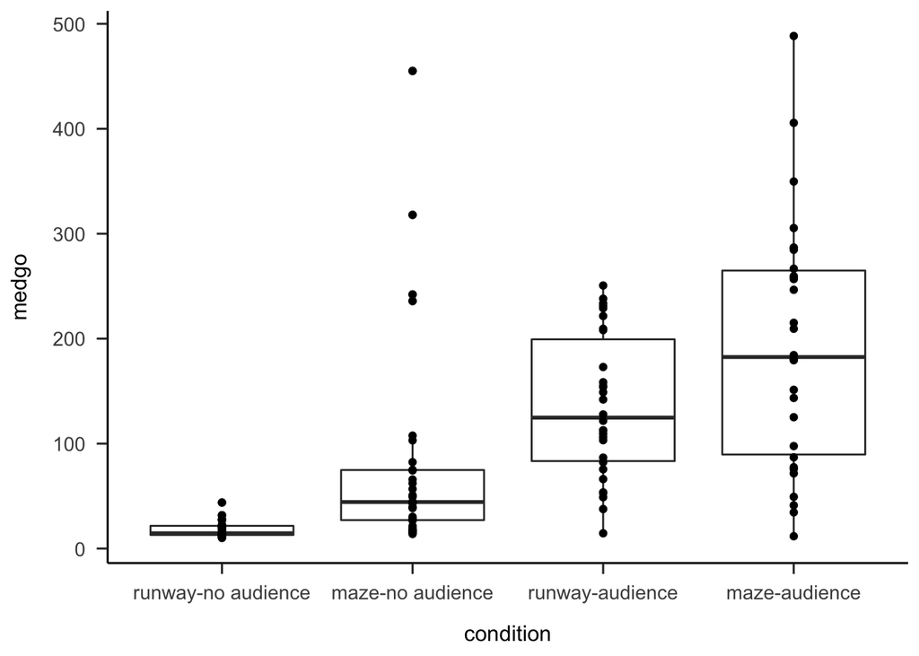

```r
go %>%
  ggplot(aes(x = condition, y = medgo)) +
  geom_boxplot() +
  geom_point() +
  theme_apa()
```

Need to get top and bottom bars on the box lines and points with white edges. Worked out that shape = 21 allows you to use colour and fill separately for `geom_point()`.

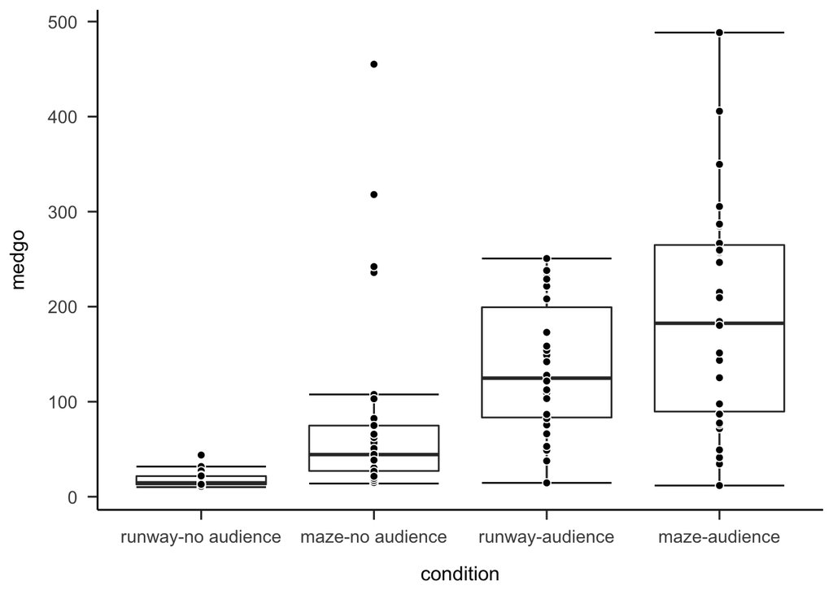

```r
go %>%
  ggplot(aes(x = condition, y = medgo)) +
  stat_boxplot(geom ='errorbar') +
  geom_boxplot() +
  geom_point(shape = 21, colour = "white", fill = "black", size = 2) +
  theme_apa()
```

Now adding axis labels and removing tick marks to match the plot in the paper.

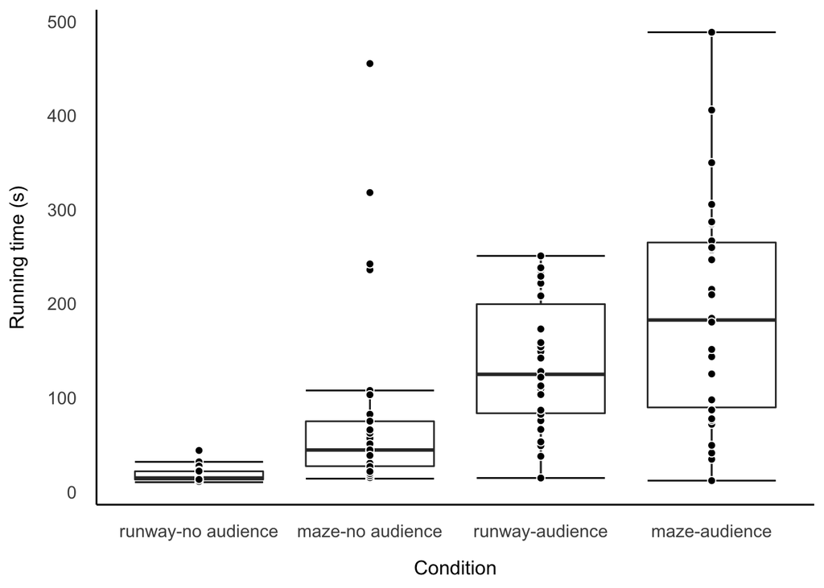

```r
go %>%
  ggplot(aes(x = condition, y = medgo)) +
  stat_boxplot(geom ='errorbar') +
  geom_boxplot() +
  geom_point(shape = 21, colour = "white", fill = "black", size = 2) +
  theme_apa() +
  labs(y = "Running time (s)", x = "Condition") +
  theme(axis.ticks = element_blank())
```

**Fig. 1**. Box-and-whisker plots showing running time in each condition of the (audience: present vs. absent) × 2 (task difficulty: runway vs. maze) between-subjects design. In each plot, the central horizontal line indicates the median, and the bottom and top edges of the box indicate the 25th and 75th percentiles, respectively. Whiskers extend to a maximum of 1.5 times the interquartile range from the 25th and 75th percentiles. Each circle is an individual data point.

> NOTE: You can add a figure caption using the chunk settings (fig.cap = ) but it seems that this figure caption is too long for that chunk option. It doesn’t work. It works just as well to put the figure text below the chunk.

# Exploratory analysis

### what is the name of the fastest cockroach?

I love that the authors included not just subjectID for each cockroach but also their names!

I want to know what the name of the roach that “won” the maze vs. the runway.

```r
names <- roaches %>%
  select(name, difficulty, med_rt_sl)

names %>%
  filter(difficulty == "runway") %>%
  arrange(med_rt_sl) %>%
  head(1)
```

```
## # A tibble: 1 x 3
##   name  difficulty med_rt_sl
##   <chr> <chr>          <dbl>
## 1 Léona runway          10.1
```

```r
names %>%
  filter(difficulty == "maze") %>%
  arrange(med_rt_sl) %>%
  head(1)
```

```
## # A tibble: 1 x 3
##   name  difficulty med_rt_sl
##   <chr> <chr>          <dbl>
## 1 Arya  maze            11.7
```

Leona and Arya are the fastest cockroaches. Game of Thrones reference perhaps?

### does temp or humidity make a difference to cockroach performance?

The dataframe also includes variables for colony and lab temperature and humidity. The researchers need to move the roaches from the colony to the lab for testing; maybe they were worried that changing conditions impacted performance. Lets test that.

Making a new dataframe with just key variables.

```r
env <- roaches %>%
  select(vp_code, audience, difficulty, med_rt_sl, starts_with("air"), starts_with("temp"))

glimpse(env)
```

```
## Rows: 120
## Columns: 8
## $ vp_code    <chr> "001", "002", "003", "004", "005", "006", "007", "008", "0…
## $ audience   <chr> "absent", "absent", "absent", "absent", "absent", "absent"…
## $ difficulty <chr> "runway", "runway", "runway", "runway", "runway", "runway"…
## $ med_rt_sl  <dbl> 21.030, 17.040, 13.825, 31.745, 12.375, 18.465, 27.170, 19…
## $ air_th     <dbl> NA, NA, NA, NA, NA, NA, NA, NA, NA, NA, NA, NA, NA, NA, NA…
## $ air_lab    <dbl> NA, NA, NA, NA, NA, NA, NA, NA, NA, NA, NA, NA, NA, NA, NA…
## $ temp_th    <dbl> NA, NA, NA, NA, NA, NA, NA, NA, NA, NA, NA, NA, NA, NA, NA…
## $ temp_lab   <dbl> NA, NA, NA, NA, NA, NA, NA, NA, NA, NA, NA, NA, NA, NA, NA…
```

Seems like there is a lot of missed env data. Using `vis_miss()` from the `naniar` package to visualise possible patterns in missing data.

```r
 vis_miss(env)
```

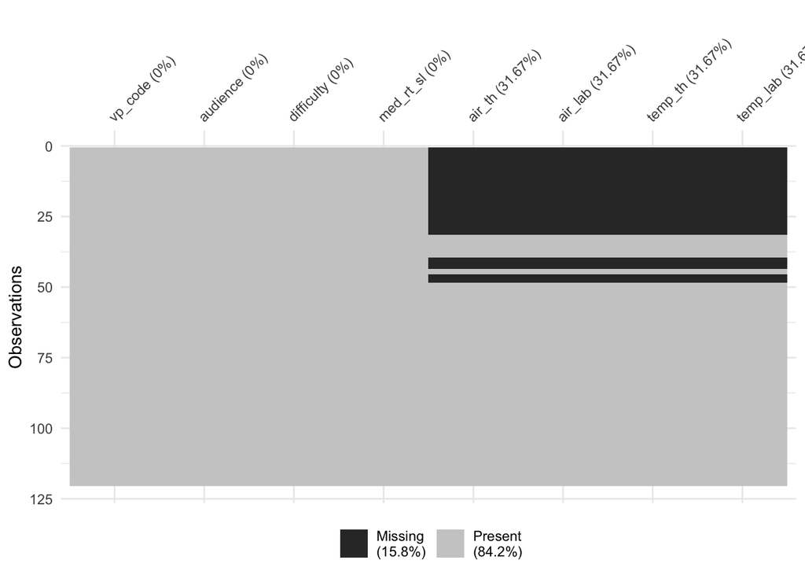

Looks like maybe they only decided to start measuring temperature and humidity part way into the experiment? Add new variables using `mutate()` that calculate the change in temperature and humidity from colony to lab.

```r
env_new <- env %>%
  mutate(temp_diff = temp_th - temp_lab,
         air_diff = air_th - air_lab)
```

Plot the relation between temperature/humidity change and performance, facetting for task difficulty.

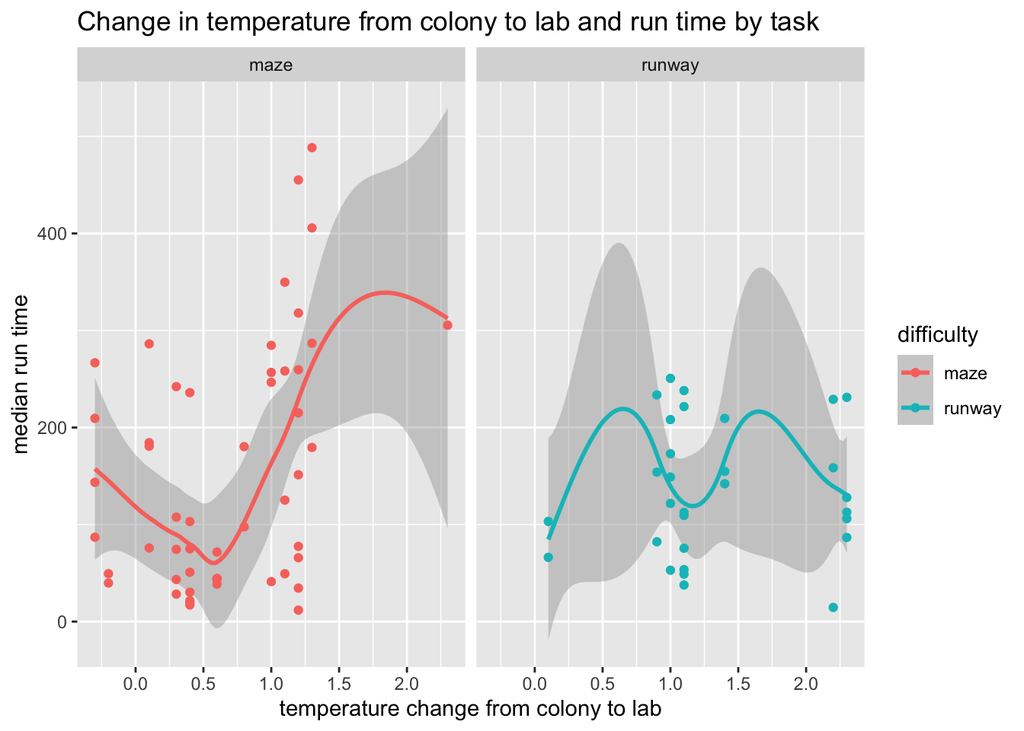

```r
env_new %>%
  ggplot(aes(x = temp_diff, y = med_rt_sl, colour = difficulty)) +
  geom_smooth() +
  geom_point() +
  facet_wrap(~difficulty) +
  labs(title = "Change in temperature from colony to lab and run time by task",
       x = "temperature change from colony to lab",
       y = "median run time")
```

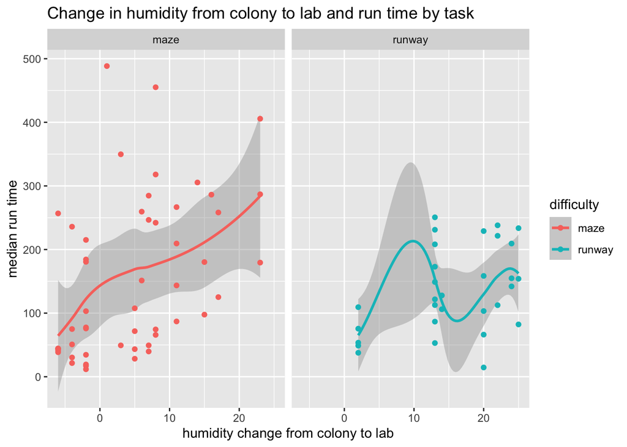

```r
env_new %>%
  ggplot(aes(x = air_diff, y = med_rt_sl, colour = difficulty)) +
  geom_smooth() +
  geom_point() +
  facet_wrap(~difficulty) +
  labs(title = "Change in humidity from colony to lab and run time by task",
       x = "humidity change from colony to lab",
       y = "median run time")
```

Interesting… looks like for maze performance the greater the change in temperature and humidity the slower the run time.

### do the roaches learn?

As a researcher more interested in learning/memory than the social lives of roaches, it is CRAZY to me that this analysis was conducted averaging across trial. I am super interested in whether the roaches ran the maze (or the runway for that matter) faster on trial 10 than on trial 1.

First, use mutate() and recode() from `dplyr` to change the trial levels.

```r
go_time <- go_time %>%
  mutate(trial = recode(trial, rt_sl01 = "trial1",  rt_sl02= "trial2", rt_sl03= "trial3",rt_sl04="trial4",
                        rt_sl05= "trial5",  rt_sl06="trial6",rt_sl07= "trial7", rt_sl08 = "trial8",  rt_sl09 ="trial9",
                        rt_sl10=  "trial10"))

go_time$trial <- as_factor(go_time$trial)


levels(go_time$trial)
```

```
##  [1] "trial1"  "trial2"  "trial3"  "trial4"  "trial5"  "trial6"  "trial7"
##  [8] "trial8"  "trial9"  "trial10"
```

Plot raw data by trial, separately for runway and maze task.

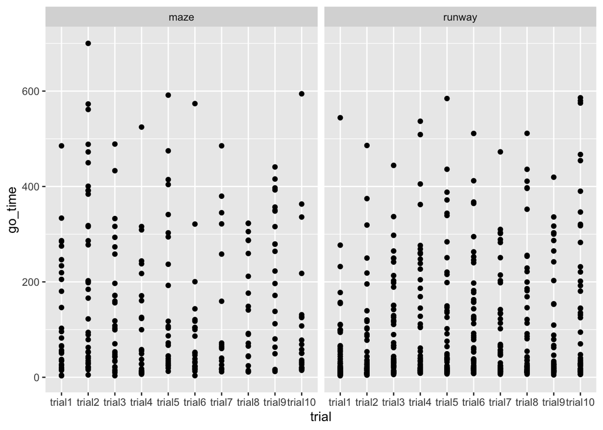

```r
go_time %>%
  group_by(difficulty) %>%
  ggplot(aes(x = trial, y = go_time)) +
  geom_point() +
  facet_wrap(~difficulty)
```

Super hard to tell if anything is going on from this plot- there is a lot of variability.

Might be better to get the mean gotime across cockroaches for each trial and task difficulty and then plot that.

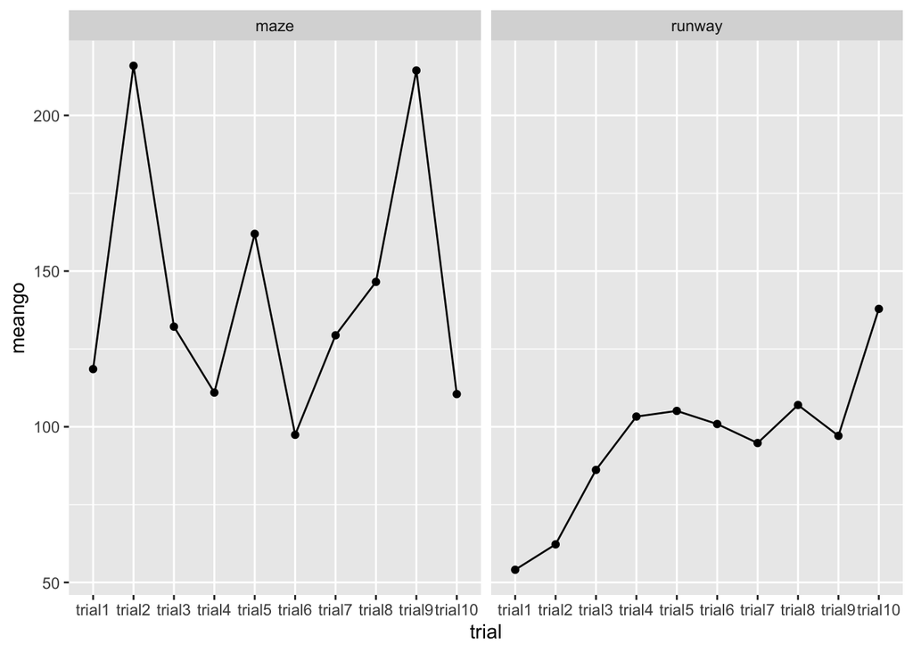

```r
go_time %>%
  group_by(trial, difficulty) %>%
  summarise(meango = mean(go_time, na.rm = TRUE)) %>%
  ggplot(aes(x = trial , y = meango, group = difficulty)) +
  geom_point() +
  geom_line() +
  facet_wrap(~difficulty)
```

Interesting… looks like the cockroaches get slower across trials for the runway task and maze performance is all over the place. Maybe I can smooth that a little by using median instead of mean. I wonder whether the pattern over trials differs for audience present vs. absent. This time including audience in the group_by() and calculating median instead. Using facet_grid() rather than facet_wrap() to get a 2 x 2 plot.

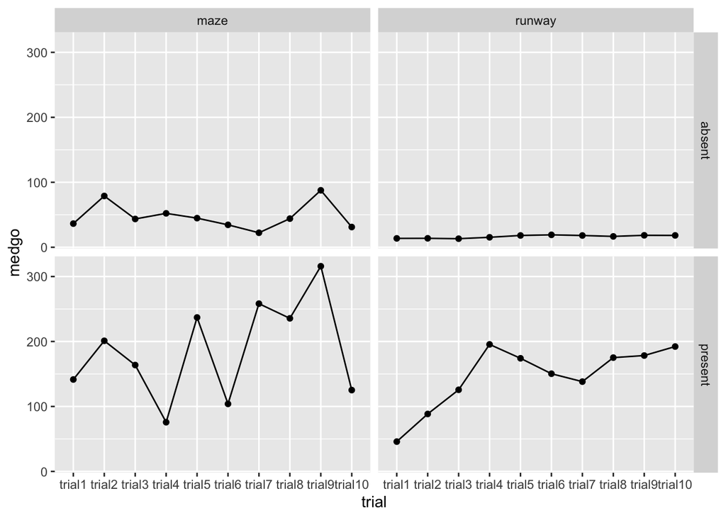

```r
go_time %>%
  group_by(trial, difficulty, audience) %>%
  summarise(medgo = median(go_time, na.rm = TRUE)) %>%
  ggplot(aes(x = trial , y = medgo, group = difficulty)) +
  geom_point() +
  geom_line() +
  facet_grid(audience~difficulty)
```

### what do these cockroaches look like?

The authors used different species of cockroach in the replication compared to the original study and talk about the potential for the failure to replicate to be due to species differences. I’m curious what the different cockroach species look like.

In the original study, they used Blatta orientalis.

[figure not shown]

```r
knitr::include_graphics(here("img", "oriental.jpeg"))
```

In the replication they used Blaberus craniifer.

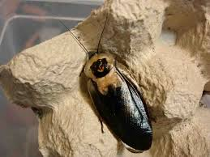

```r
knitr::include_graphics(here("img", "death_head.jpeg"))
```

They are both gross.

[interactive chart not shown]